# STSCI 4060 HW5 General Instructions:

This assignment should be done using IPython notebook. The instructions are given in several cells and you are asked to insert some Python statements in the cells righ below them and then run each cell. After you have completed, download your IPython notebook in two forms: IPython Notebook (File --> Download as --> Notebook(.ipynb)) and an HTML copy (File --> Download as --> HTML(.html)) for submission.

## Step 1 (4 points)

1. In the following cell import the Python modules that are needed for doing the KMeans clustering, 2D and 3D scatter plots.

```python
###### Step 1-1 ######
import numpy as np
import matplotlib.pyplot as plt
from mpl_toolkits.mplot3d import Axes3D
from sklearn.datasets import make_blobs
from sklearn.cluster import KMeans
```

## Step 2 (8 points)

1. In the cell below, from the data file, `iris.txt` (that can be downloaded from the coures website), create a **list** called `dataset` to hold the first three columns of the data points and another **list** called `species` to hold the values of the iris species names.
2. Display the contents of these two lists.
3. Convert the two lists to numpy arrays and keep the same names.

```python
###### Step 2-1 ######
readin = open(r"C:\Users\Harry Lu's X1\Documents\Cornell\STSCI 4060 - Python\Homework5\iris.txt")
c1 = []
c2 = []
c3 = []
#c4 = []
dataset = [c1, c2, c3]
species = []
for aline in readin:
    splits = aline.split(",")
    c1.append(splits[0])
    c2.append(splits[1])
    c3.append(splits[2])
    #c4.append(splits[3])
    temp = splits[4].split("\n")
    species.append(temp[0])

###### Step 2-2 ######
print dataset
print species

###### Step 2-3 ######
dataset = np.array(dataset)
species = np.array(species)
# print dataset
# print species
```

```
[['5.1', '4.9', '4.7', '4.6', '5.0', '5.4', '4.6', '5.0', '4.4', '4.9', '5.4', '4.8', '4.8', '4.3', '5.8', '5.7', '5.4', '5.1', '5.7', '5.1', '5.4', '5.1', '4.6', '5.1', '4.8', '5.0', '5.0', '5.2', '5.2', '4.7', '4.8', '5.4', '5.2', '5.5', '4.9', '5.0', '5.5', '4.9', '4.4', '5.1', '5.0', '4.5', '4.4…
['Iris-setosa', 'Iris-setosa', 'Iris-setosa', 'Iris-setosa', 'Iris-setosa', 'Iris-setosa', 'Iris-setosa', 'Iris-setosa', 'Iris-setosa', 'Iris-setosa', 'Iris-setosa', 'Iris-setosa', 'Iris-setosa', 'Iris-setosa', 'Iris-setosa', 'Iris-setosa', 'Iris-setosa', 'Iris-setosa', 'Iris-setosa', 'Iris-setosa',…
```

## Step 3 (2 points)

1. Convert the data type of `dataset` to **float**.
2. Display the shape of `dataset`.

```python
###### Step 3-1 ######
dataset = dataset.astype(float)

###### Step 3-1 ######
print dataset.shape
```

```
(3L, 150L)
```

## Step 4 (29 points)

1. In the cell below, use the KMeans algorithm to do a K-Means cluster analysis using the first two columns of the data of the dataset array. The KMean settings are:
   - `n_cluster = 3`
   - `init = 'random'`
   - `n_init = 10`
   - `max_iter = 500`
   - `tol = 1e-4`
   - `random_state = 0`
   - Use the same settings for the rest of analyses below.
2. Then, you create two scatter plots with a total figure size of $20\times10$:
   1. A plot showing the K-Means clusting resutls.
   2. A plot showing the actual clusters (represented by flower names).
   3. These two plots should be arranged in a $1\times2$ grid.
   4. The K-Means plot is diaplayed in position 1 and the actual cluster plot is in position 2.
   5. Settings:
      - Use the same type of marker (`'o'`)
      - Set `s = 50`
      - Set labels to flower names
      - Set the colors as follows:
        - red for Iris-setosa
        - blue for Iris-versicolor
        - orange for Iris-virginica
      - Note that the cluster names of the K-Means result are represented by numbers (0,1,2), but you should be able to figure out what number represents what kind of flower by comparing the numbers to the actual cluster names.
   6. Give the title "K-Means" to the K-Means plot and "Actual" to the actual cluster plot.
   7. The legends should be displayed in the upper right corner of each plot; the two plots should have the same legends.
   8. Make sure that you have the same color code patterns for both the clusters and the legends in the two plots (same below).

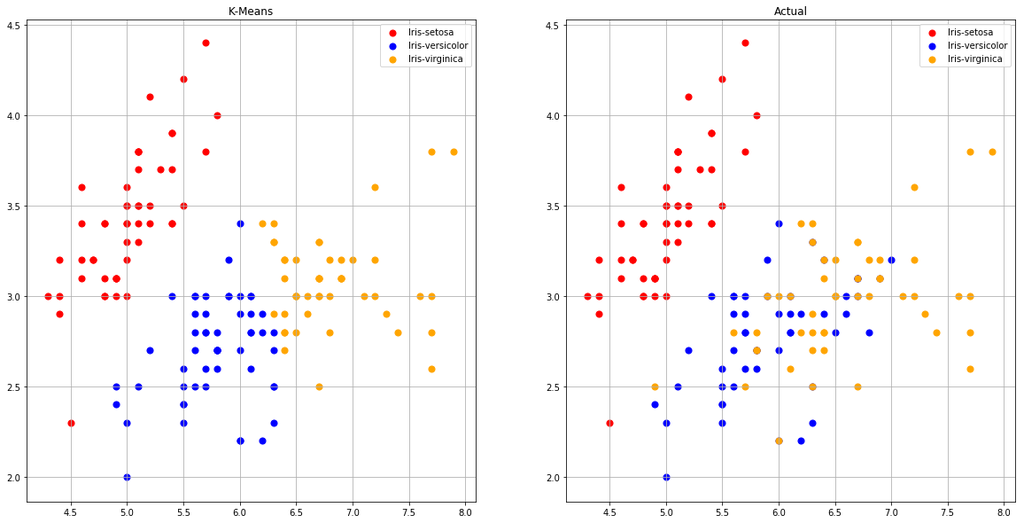

```python
###### Step 4-1 ######
column_1 = dataset[0]
column_2 = dataset[1]
l = len(column_1)
X = np.empty((l, 2))
X[:, 0] = column_1
X[:, 1] = column_2

km = KMeans(n_clusters = 3,
            init = "random",
            n_init = 10,
            max_iter = 500,
            tol = 1e-04,
            random_state = 0)
y_km = km.fit_predict(X)

###### Step 4-2 ######
fig = plt.figure(figsize = (20, 10))

fig_km = fig.add_subplot(121, projection = None)
fig_km.scatter(X[y_km == 1, 0],
               X[y_km == 1, 1],
               s = 50,
               c = "red",
               marker = "o",
               label = "Iris-setosa")
fig_km.scatter(X[y_km == 0, 0],
               X[y_km == 0, 1],
               s = 50,
               c = "blue",
               marker = "o",
               label = "Iris-versicolor")
fig_km.scatter(X[y_km == 2, 0],
               X[y_km == 2, 1],
               s = 50,
               c = "orange",
               marker = "o",
               label = "Iris-virginica")
fig_km.legend(loc = "upper right")
fig_km.grid()
fig_km.set_title("K-Means")

fig_actual = fig.add_subplot(122, projection = None)
fig_actual.scatter(X[species == "Iris-setosa", 0],
                   X[species == "Iris-setosa", 1],
                   s = 50,
                   c = "red",
                   marker = "o",
                   label = "Iris-setosa")
fig_actual.scatter(X[species == "Iris-versicolor", 0],
                   X[species == "Iris-versicolor", 1],
                   s = 50,
                   c = "blue",
                   marker = "o",
                   label = "Iris-versicolor")
fig_actual.scatter(X[species == "Iris-virginica", 0],
                   X[species == "Iris-virginica", 1],
                   s = 50,
                   c = "orange",
                   marker = "o",
                   label = "Iris-virginica")
fig_actual.legend(loc = "upper right")
fig_actual.grid()
fig_actual.set_title("Actual")

plt.show()
```

## Step 5 (29 points)

1. You may get a different clustering result when use a different set of data points. Use the same analysis with the same settings as the above analysis but use the second and third columns of the dataset array.
2. Note that the cluster numbers of this K-Means analysis result may be different from the meaning of the result produced in the above analysis, so you may have to match the cluster numbers with the actual cluster names again.
3. By looking at the scatter plots, you should see which group of the data points represents the actual situation better; add a cell below your result of the following cell to write your comments.

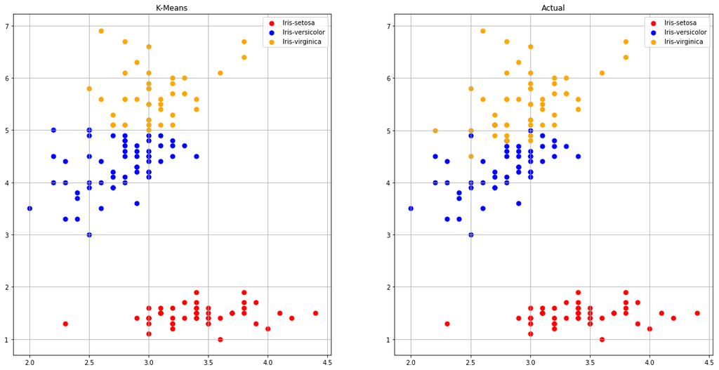

```python
column_2 = dataset[1]
column_3 = dataset[2]
l = len(column_1)
Y = np.empty((l, 2))
Y[:, 0] = column_2
Y[:, 1] = column_3

km = KMeans(n_clusters = 3,
            init = "random",
            n_init = 10,
            max_iter = 500,
            tol = 1e-04,
            random_state = 0)
y_km = km.fit_predict(Y)

fig = plt.figure(figsize = (20, 10))

fig_km = fig.add_subplot(121, projection = None)
fig_km.scatter(Y[y_km == 2, 0],
               Y[y_km == 2, 1],
               s = 50,
               c = "red",
               marker = "o",
               label = "Iris-setosa")
fig_km.scatter(Y[y_km == 1, 0],
               Y[y_km == 1, 1],
               s = 50,
               c = "blue",
               marker = "o",
               label = "Iris-versicolor")
fig_km.scatter(Y[y_km == 0, 0],
               Y[y_km == 0, 1],
               s = 50,
               c = "orange",
               marker = "o",
               label = "Iris-virginica")
fig_km.legend(loc = "upper right")
fig_km.grid()
fig_km.set_title("K-Means")

fig_actual = fig.add_subplot(122, projection = None)
fig_actual.scatter(Y[species == "Iris-setosa", 0],
                   Y[species == "Iris-setosa", 1],
                   s = 50,
                   c = "red",
                   marker = "o",
                   label = "Iris-setosa")
fig_actual.scatter(Y[species == "Iris-versicolor", 0],
                   Y[species == "Iris-versicolor", 1],
                   s = 50,
                   c = "blue",
                   marker = "o",
                   label = "Iris-versicolor")
fig_actual.scatter(Y[species == "Iris-virginica", 0],
                   Y[species == "Iris-virginica", 1],
                   s = 50,
                   c = "orange",
                   marker = "o",
                   label = "Iris-virginica")
fig_actual.legend(loc = "upper right")
fig_actual.grid()
fig_actual.set_title("Actual")

plt.show()
```

## Step 6 (28 points)

1. Now do your K-Means analysis again using all the three colums of dataset. In this case, you need to create a 3D scatter plot, using the same settings for plotting, except arranging the two plots in a $2\times1$ grid.

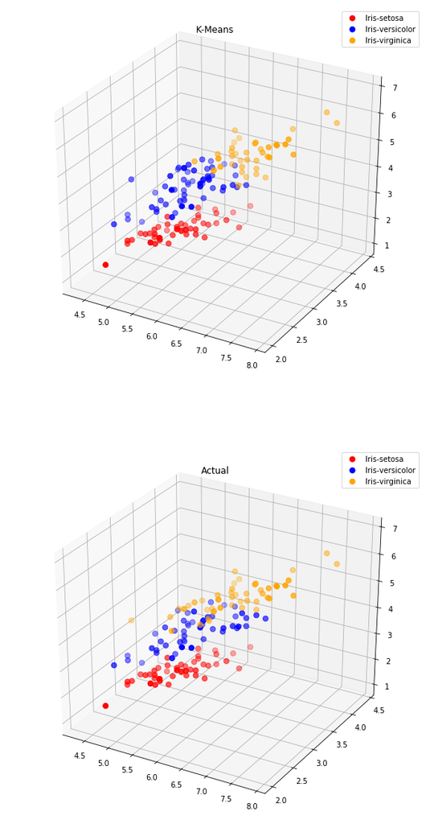

```python
column_1 = dataset[0]
column_2 = dataset[1]
column_3 = dataset[2]
l = len(column_1)
Z= np.empty((l, 3))
Z[:, 0] = column_1
Z[:, 1] = column_2
Z[:, 2] = column_3

km = KMeans(n_clusters = 3,
            init = "random",
            n_init = 10,
            max_iter = 500,
            tol = 1e-04,
            random_state = 0)
y_km = km.fit_predict(Z)

fig = plt.figure(figsize = (10, 20))

fig_km = fig.add_subplot(211, projection = "3d")
fig_km.scatter(Z[y_km == 2, 0],
               Z[y_km == 2, 1],
               Z[y_km == 2, 2],
               s = 50,
               c = "red",
               marker = "o",
               label = "Iris-setosa")
fig_km.scatter(Z[y_km == 1, 0],
               Z[y_km == 1, 1],
               Z[y_km == 1, 2],
               s = 50,
               c = "blue",
               marker = "o",
               label = "Iris-versicolor")
fig_km.scatter(Z[y_km == 0, 0],
               Z[y_km == 0, 1],
               Z[y_km == 0, 2],
               s = 50,
               c = "orange",
               marker = "o",
               label = "Iris-virginica")
fig_km.legend(loc = "upper right")
fig_km.grid()
fig_km.set_title("K-Means")

fig_actual = fig.add_subplot(212, projection = "3d")
fig_actual.scatter(Z[species == "Iris-setosa", 0],
                   Z[species == "Iris-setosa", 1],
                   Z[species == "Iris-setosa", 2],
                   s = 50,
                   c = "red",
                   marker = "o",
                   label = "Iris-setosa")
fig_actual.scatter(Z[species == "Iris-versicolor", 0],
                   Z[species == "Iris-versicolor", 1],
                   Z[species == "Iris-versicolor", 2],
                   s = 50,
                   c = "blue",
                   marker = "o",
                   label = "Iris-versicolor")
fig_actual.scatter(Z[species == "Iris-virginica", 0],
                   Z[species == "Iris-virginica", 1],
                   Z[species == "Iris-virginica", 2],
                   s = 50,
                   c = "orange",
                   marker = "o",
                   label = "Iris-virginica")
fig_actual.legend(loc = "upper right")
fig_actual.grid()
fig_actual.set_title("Actual")

plt.show()
```